# Презентация по лабораторной работе №12

Дисциплина: Администрирование локальных сетей

Лобанова П.И.

Российский университет дружбы народов, Москва, Россия

21 апреля 2025

# Информация

## Докладчик

- Лобанова Полина Иннокентьевна
- Учащаяся на направлении “Фундаментальная информатика и информационные технологии”
- Студентка группы НФИбд-02-22
- polla-2004@mail.ru

# Цель

Приобретение практических навыков по настройке доступа локальной сети к внешней сети посредством NAT.

# Постановка задачи

1. сеть управления устройствами не должна иметь доступ в Интернет;
2. оконечные устройства сети дисплейных классов должны иметь доступ только к сайтам, необходимым для учёбы (в данном случае к www.yandex.ru, stud.rudn.university);
3. пользователям из сети кафедр разрешено работать только с образовательными сайтами (в данном случае это esystem.pfur.ru);
4. пользователям сети администрации разрешено работать только с сайтом университета www.rudn.ru;
5. в сети для других пользователей компьютер администратора должен иметь полный доступ во внешнюю сеть, а другие пользователи — не должны выходить в Интернет;
6. ограничения для серверов:

– WEB-сервер должен быть доступен по порту 80;

– почтовый сервер должен быть доступен по портам 25 и 110;

– файловый сервер должен быть доступен извне по портам протокола FTP;

7. компьютер администратора должен быть доступен из внешней сети по протоколу удалённого рабочего стола (Remote Desktop Protocol, RDP).

# Задание

1. Сделать первоначальную настройку маршрутизатора provider-gw-1 и коммутатора provider-sw-1 провайдера: задать имя, настроить доступ по паролю и т.п.
2. Настроить интерфейсы маршрутизатора provider-gw-1 и коммутатора provider-sw-1 провайдера.
3. Настроить интерфейсы маршрутизатора сети «Донская» для доступа к сети провайдера.
4. Настроить на маршрутизаторе сети «Донская» NAT с правилами, указанными в разделе 12.2.
5. Настроить доступ из внешней сети в локальную сеть организации, как указано в разделе 12.2.
6. Проверить работоспособность заданных настроек.
7. При выполнении работы необходимо учитывать соглашение об именовании.

# Выполнение

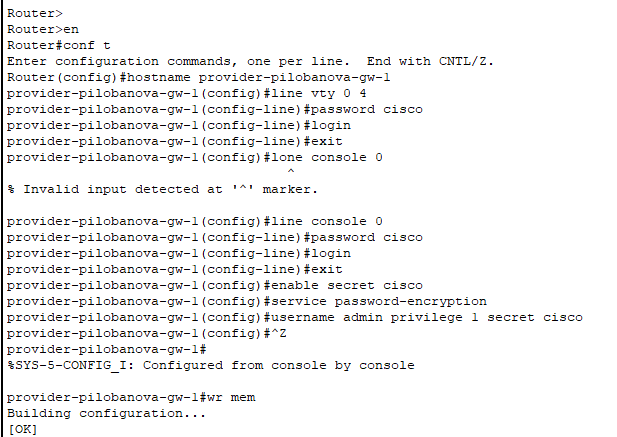

*Первоначальная настройка маршрутизатора provider-gw-1*

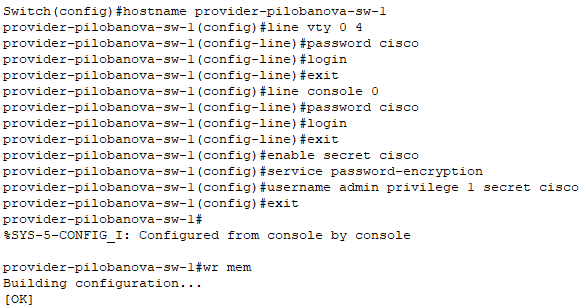

*Первоначальная настройка коммутатора provider-sw-1*

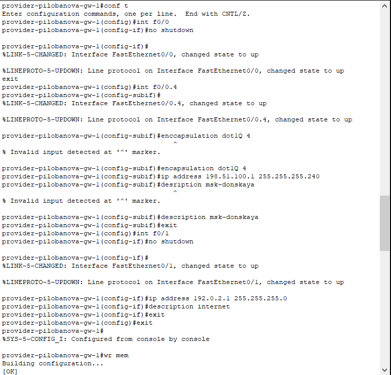

*Настройка интерфейсов маршрутизатора provider-gw-1*

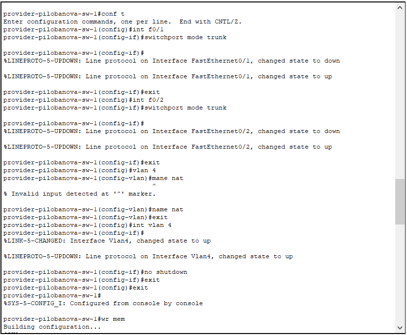

*Настройка интерфейсов коммутатора provider-sw-1*

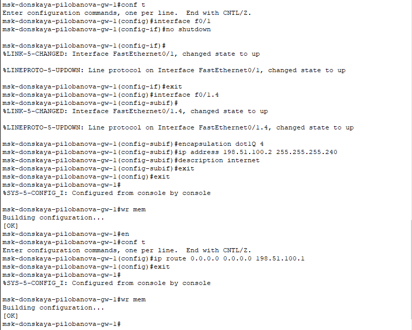

*Настройка интерфейсов маршрутизатораmsk-donskaya-gw-1*

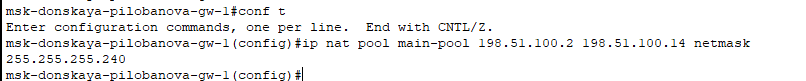

*Настройка пула адресов для NAT*

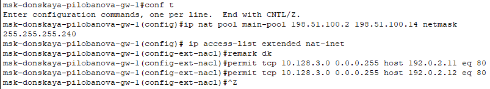

*Настройка списка доступа для NAT (Сеть дисплейных классов)*

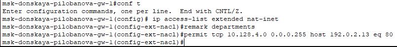

*Настройка списка доступа для NAT (Сеть кафедр)*

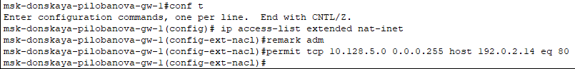

*Настройка списка доступа для NAT (Сеть администрации)*

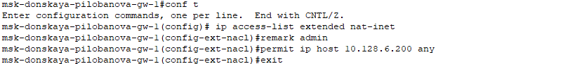

*Настройка списка доступа для NAT (Доступ для компьютера администратора)*

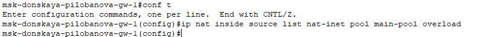

*Настройка Port Address Translation*

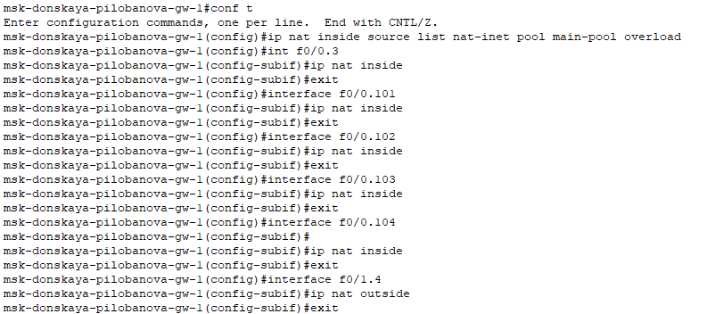

*Настройка интерфейсов для NAT*

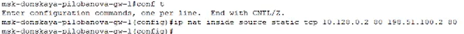

*Настройка доступа из Интернета (WWW-сервер)*

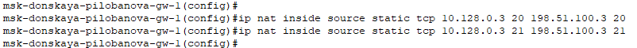

*Настройка доступа из Интернета (Файловый сервер)*

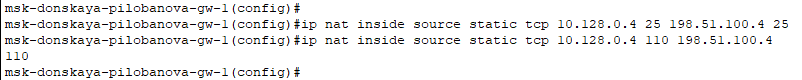

*Настройка доступа из Интернета (Почтовый сервер)*

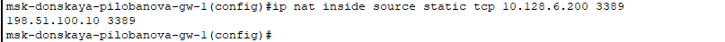

*Настройка доступа из Интернета ( Доступ по RDP)*

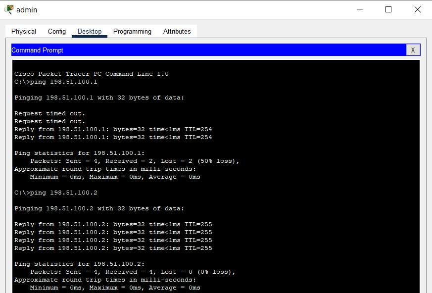

*Проверка работоспособности*

[figure not shown]

*Проверка работоспособности*

[figure not shown]

*Проверка работоспособности*

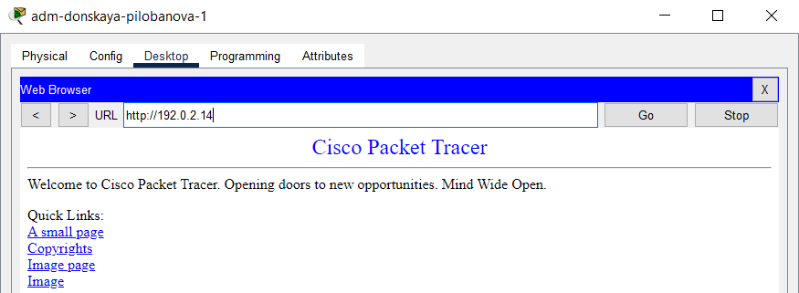

*Проверка работоспособности*

# Вывод

Я приобрела практические навыки по настройке доступа локальной сети к внешней сети посредством NAT.